# Problem set 1: Berryman, chapters 1–3

## Chapter 1. Dynamics: theoretical ecoology and the rules of change

Deer feed on certain woody shrubs and in so doing can severely reduce their abundance. Shrubs and trees compete with each other for space, sunlight, nutrients, and water. Therefore, the more trees the less shrubs and vice versa. Shrubs, of course, are good for deer, but so are trees, for they provide protection. Draw the feedback structure of this system. How many feedback processes are there and are they negative or positive? Describe these feedback processes and explain how this system can be stabilized.

**Note 1**: Draw by hand, take a photo. Embed that photo in your RMarkdown document by (1) placing your image in the same folder as your RMarkdown document and (2) typing `![]()` and inserting your filename into the parentheses; e.g., `![alt text](image.jpg)`.

**Note 2**: This question wasn’t super clear to me, so instead of answering *How many feedback processes are there and are they negative or positive? Describe these feedback processes and explain how this system can be stabilized.*, answer: If you were to increase the abundance of each of the variables, one at a time, how would that affect the other two?

## Chapter 2. Population: the central concept

2.1. 758 elk spend 3 months each winter in a 5 hectare feed lot. These elk are known to range over a watershed of 1230 hectares. What is the absolute size of the population and what is its density?

2.2. A scientist sampled the white grubs in a 3.4 hectare pasture by taking 200 randomly located 1 decimeter (= 10 square centimeters) soil cores. He counted 7564 white grubs in these samples. Calculate the density of white grubs per square meter of soil, per hectare, and the absolute population in the pasture.

2.3. The elk population discussed above produced 58 calves in 1990 but only 22 were alive by 1990 December 30. In addition, 37 yearling and older elk died during 1990. What was the per capita birth and death rate and the logarithmic net per capita rate of change (R) over the year? Is this elk population increasing?

**Note**: Remember that elk have sexes, so let’s assume that the female:male is 1:1.

## Chapter 3. The first principle: exponential growth

3.1. If you have $10,000 in the bank at 10% annual interest rate, how much will you have in 10 years if the interest is compounded at the end of each year? What is the relationship between the interest rate and population parameters $G$, $R$, $B$, and $D$?

3.2. Simulate the dynamics of a population for 10 years using equation (3.13) when the initial density is 10 individuals, the per capita rate of change is $R = 0.8$ and the standard deviation is zero. Plot the trajectory on both arithmetic and logarithmic scales.

**Note 1**: We will be spending a lot of time on this next week. For now, here is the short of it for you to adapt to this question:

```r
# Create an empty vector for 20 years
  years <- 20
  year_vec <- 1:years
  N_vec <- rep(x = NA, times = years)
# Set the initial population size at the first year
  N_vec[1] <- 42
# Set the parameters
  R <- 1.01
  s <- 1
# Write a "loop" that iterates with "i", in this case, taking the value of every year
  for (i in 2:years) {
    Ntm1 <- N_vec[i - 1]
    Z <- rnorm(n = 1, mean = 0, sd = s)
    Nt <- Ntm1*exp(R + Z)
    N_vec[i] <- Nt
  }
```

**Note 2**: The simplest way to plot on a logarithmic scale is to log your variables. For example:

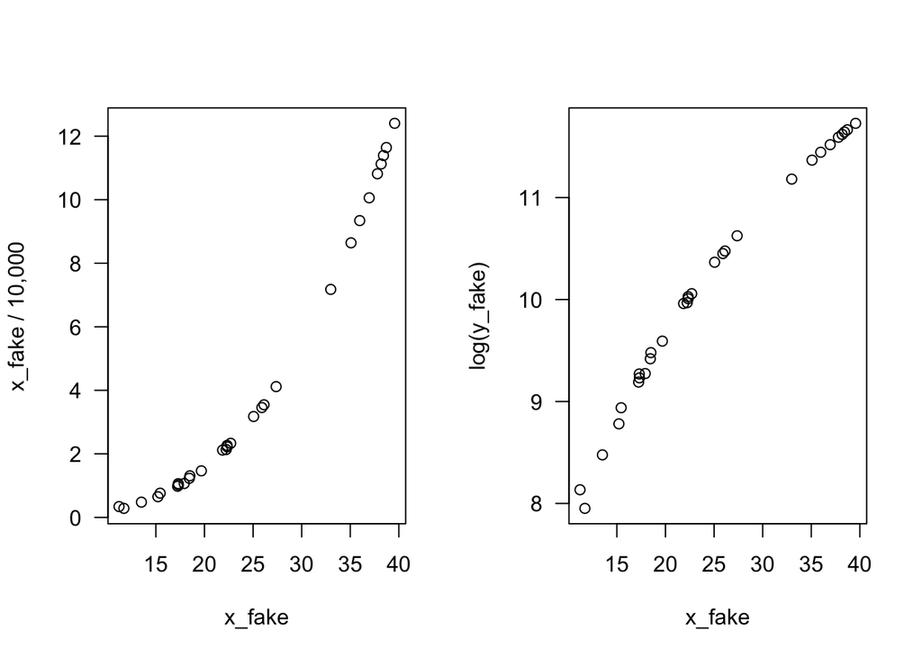

```r
# Here, I make up data
  n_samps <- 30
  x_fake <- runif(n = n_samps, min = 10, max = 40)
  y_fake <- 2*x_fake^3 + 10 + rnorm(n = n_samps, sd = 300, mean = 0)
# Plot
  par(mfrow = c(1, 2), las = 1) # This is how you make a plot with 1 row and 2 columns
  plot(x = x_fake, y = y_fake/10000, ylab = "x_fake / 10,000")
  plot(x = x_fake, y = log(y_fake))
```

**Note 3**: Just plot the vertical axis as logarithmic here and in the next problem.

3.3. Simulate the dynamics of a population governed by equation (3.13) under the same conditions as before but with the standard deviation 0.2. Plot the trajectory on both arithmetic and logarithmic scales.